# DS01-Project all activities -Nizam

# scatterplot

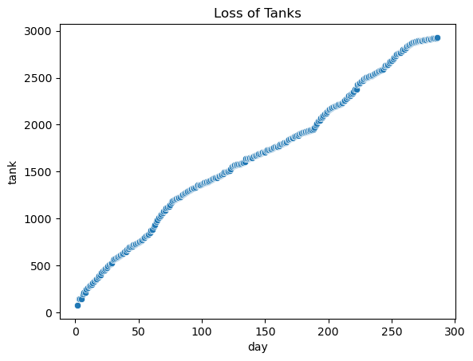

```python
#This code uses seaborn's scatterplot function to create a scatter
#plot with the 'day' attribute on the x-axis and the 'tank' attribute on the
#y-axis from the Dataset1_csv DataFrame. The plot is then displayed
#y-axis from the Dataset1_csv DataFrame. The plot is then displayed
#with the title 'Loss of Tanks' using plt.title() and plt.show() functions.

# Scatter plot for Tanks
sns.scatterplot(x='day', y='tank', data=Dataset1_csv)
plt.title('Loss of Tanks')
plt.show()
```

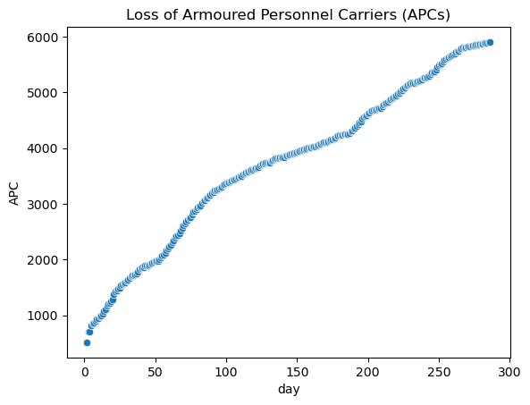

```python
# Scatter plot for Armoured Personnel Carriers (APCs)
sns.scatterplot(x='day', y='APC', data=Dataset1_csv)
plt.title('Loss of Armoured Personnel Carriers (APCs)')
plt.show()
```

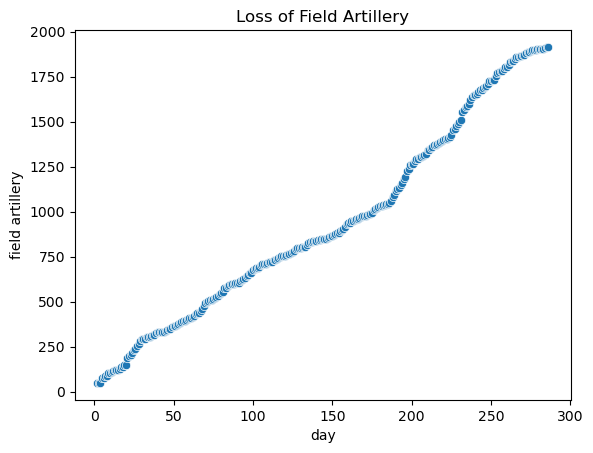

```python
# Scatter plot for field Artillery
sns.scatterplot(x='day', y='field artillery', data=Dataset1_csv)
plt.title('Loss of Field Artillery')
plt.show()
```

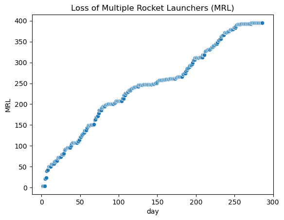

```python
# Scatter plot for Multiple Rocket Launchers (MRL)
sns.scatterplot(x='day', y='MRL', data=Dataset1_csv)
plt.title('Loss of Multiple Rocket Launchers (MRL)')
plt.show()
```

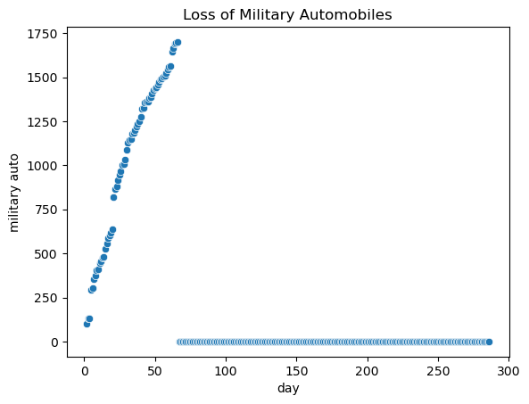

```python
# Scatter plot for military automobiles
sns.scatterplot(x='day', y='military auto', data=Dataset1_csv)
plt.title('Loss of Military Automobiles')
plt.show()
```

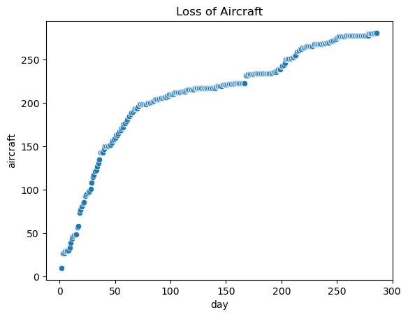

```python
# Scatter plot for aircraft
sns.scatterplot(x='day', y='aircraft', data=Dataset1_csv)
plt.title('Loss of Aircraft')
plt.show()
```

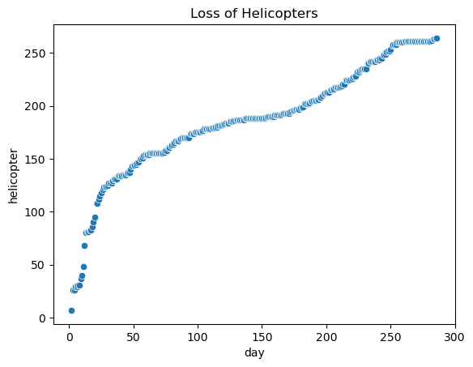

```python
# Scatter plot for helicopters
sns.scatterplot(x='day', y='helicopter', data=Dataset1_csv)
plt.title('Loss of Helicopters')
plt.show()
```

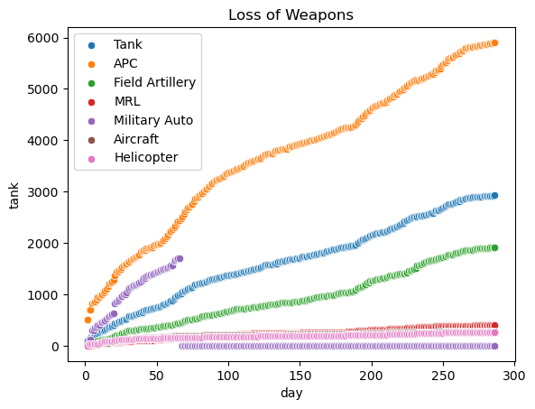

```python
#this code, sns.scatterplot is used multiple times to create a
#scatter plot for each weapon attribute. Each scatter plot represents
#the loss of a specific weapon, such as 'Tank', 'APC', 'Field Artillery',
#'MRL', 'Military Auto', 'Aircraft', and 'Helicopter'. The x-axis represents
#the days, and the y-axis represents the count or loss of each weapon.

#The label parameter is used to provide a label for each scatter
#plot, which will be used in the legend.

#After creating all the scatter plots, plt.title is used to set the title
#of the plot as 'Loss of Weapons'. plt.legend() is used to display a
#legend that indicates the corresponding weapon for each scatter plot.

#Finally, plt.show() is called to display the plot.
#This all-in-one scatter plot allows you to compare the loss of different
#weapons over time and observe any patterns or trends in the data.


# All-in-one scatter plot for the loss of all weapons
sns.scatterplot(x='day', y='tank', data=Dataset1_csv, label='Tank')
sns.scatterplot(x='day', y='APC', data=Dataset1_csv, label='APC')
sns.scatterplot(x='day', y='field artillery', data=Dataset1_csv, label='Field Artillery')
sns.scatterplot(x='day', y='MRL', data=Dataset1_csv, label='MRL')
sns.scatterplot(x='day', y='military auto', data=Dataset1_csv, label='Military Auto')
sns.scatterplot(x='day', y='aircraft', data=Dataset1_csv, label='Aircraft')
sns.scatterplot(x='day', y='helicopter', data=Dataset1_csv, label='Helicopter')

plt.title('Loss of Weapons')
plt.legend()
plt.show()
```

# heatmap

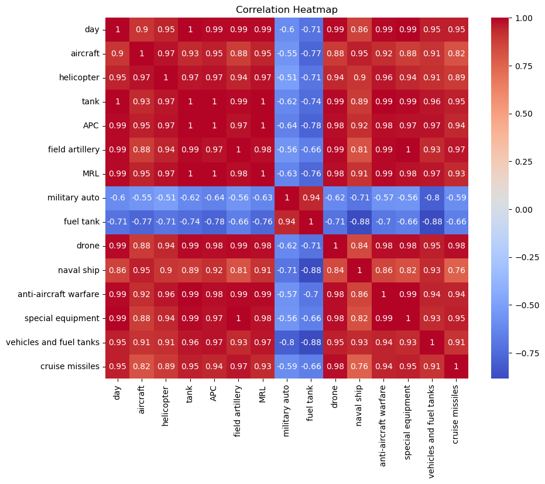

```python
#In this part, the corr() function is applied to Dataset1_csv to
#This results in a correlation matrix that measures
#the linear relationships between each pair of columns in the dataset.

#In this part, plt.figure(figsize=(10, 8)) sets the figure size of
#the heatmap. sns.heatmap is then used to create the heatmap, with
#the corr_matrix as the data source. The annot=True parameter
#adds the correlation values to the heatmap cells. The cmap='coolwarm'
#parameter sets the color map to coolwarm, which represents negative
#correlations with cool colors and positive correlations with warm colors.

#Finally, plt.title is used to set the title of the heatmap as
#Correlation Heatmap', and plt.show() is called to display the heatmap.



# Calculate the correlation matrix
corr_matrix = Dataset1_csv.corr()

# Create a heatmap
plt.figure(figsize=(10, 8))
sns.heatmap(corr_matrix, annot=True, cmap='coolwarm')
plt.title('Correlation Heatmap')
plt.show()
```

The correlation heatmap provides valuable insights into the relationships between different variables. In this case, we observe a negative correlation, represented by the blue color. Specifically, the attributes 'military auto' and 'fuel tank' fall into the blue category, indicating an inverse relationship with the other variables in the dataset. This implies that as one variable increases, the other tends to decrease, highlighting a potential interdependency between 'military auto', 'fuel tank', and the other variables in the dataset.

# histogram

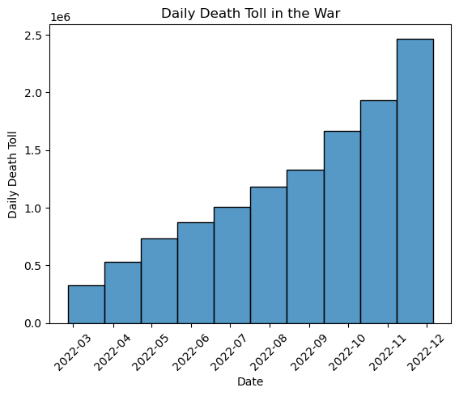

```python
#code selects the 'date' and 'personnel' columns from Dataset2_csv
#and creates a histogram to analyze the daily death toll in the war.

#This line extracts the 'date' and 'personnel' columns from Dataset2_csv
#and assigns them to the date_personnel DataFrame.

#Here, the 'date' column in date_personnel is converted to datetime
#format using the pd.to_datetime() function.

#This line creates a histogram using the sns.histplot() function.
#The data source is date_personnel, and the 'date' column is
#plotted on the x-axis. The 'personnel' column is used as weights,
#which means the histogram will show the sum of 'personnel' values for each date.

#The plt.xticks(rotation=45) line rotates the x-axis labels by 45
#degrees to improve readability. Finally, plt.show() is called to display the histogram plot.





# Select the 'date' and 'personnel' columns
date_personnel = Dataset2_csv[['date', 'personnel']]

# Convert the 'date' column to datetime
date_personnel['date'] = pd.to_datetime(date_personnel['date'])

# Plot the histogram for the daily death toll
sns.histplot(data=date_personnel, x='date', weights='personnel')

# Set the x-axis label
plt.xlabel('Date')

# Set the y-axis label
plt.ylabel('Daily Death Toll')

# Set the title
plt.title('Daily Death Toll in the War')

# Rotate the x-axis labels for better readability
plt.xticks(rotation=45)

# Display the plot
plt.show()
```

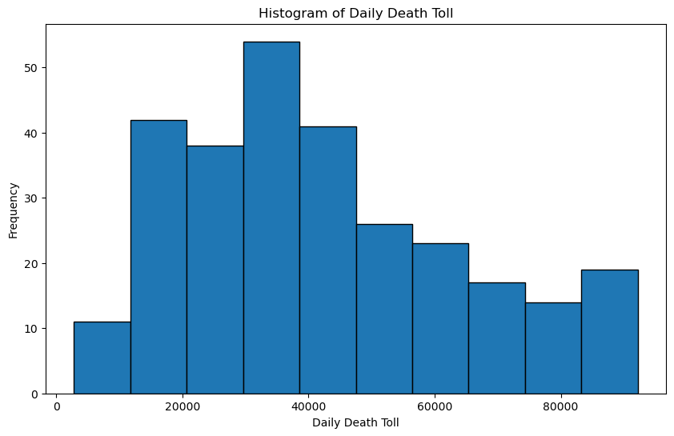

```python
#The updated code converts the 'date' column in Dataset2_csv to
#datetime format using pd.to_datetime(). Then, it calculates the
#daily death toll by grouping the data by date and summing the
#'personnel' column. Finally, a histogram is plotted to visualize the
#frequency distribution of the daily death toll.

#using groupby(), and the 'personnel'
#column is summed for each date to calculate the daily death toll.

#A histogram is created using plt.hist(). The
#daily_death_toll values are used as the input, and bins=10
#specifies the number of bins or bars in the histogram. The
#edgecolor='black' argument sets the color of the edges of the
#bars. The x-axis is labeled as 'Daily Death Toll', the y-axis as
#Frequency', and the title is set as 'Histogram of Daily Death Toll'.
#Finally, plt.show() displays the histogram plot.



# Convert 'date' column to datetime format
Dataset2_csv['date'] = pd.to_datetime(Dataset2_csv['date'])

# Calculate the daily death toll by grouping the data by date and summing the 'personnel' column
daily_death_toll = Dataset2_csv.groupby('date')['personnel'].sum()

# Plot the histogram
plt.figure(figsize=(10, 6))
plt.hist(daily_death_toll, bins=10, edgecolor='black')
plt.xlabel('Daily Death Toll')
plt.ylabel('Frequency')
plt.title('Histogram of Daily Death Toll')
plt.show()
```